# Graph Analytics

Kyu Cho

February 13, 2016

## Introduction

In this problem, we’ll see how clustering can be used to find similar groups of customers who belong to an airline’s frequent flyer program. The airline is trying to learn more about its customers so that it can target different customer segments with different types of mileage offers.

The file AirlinesCluster.csv contains information on 3,999 members of the frequent flyer program.

## Variables

Balance = number of miles eligible for award travel  
QualMiles = number of miles qualifying for TopFlight status  
BonusMiles = number of miles earned from non-flight bonus transactions in the past 12 months  
BonusTrans = number of non-flight bonus transactions in the past 12 months  
FlightMiles = number of flight miles in the past 12 months  
FlightTrans = number of flight transactions in the past 12 months  
DaysSinceEnroll = number of days since enrolled in the frequent flyer progra

```r
setwd("F:")
airlines = read.csv("AirlinesCluster.csv")
summary(airlines)
```

```
##     Balance          QualMiles         BonusMiles       BonusTrans
##  Min.   :      0   Min.   :    0.0   Min.   :     0   Min.   : 0.0
##  1st Qu.:  18528   1st Qu.:    0.0   1st Qu.:  1250   1st Qu.: 3.0
##  Median :  43097   Median :    0.0   Median :  7171   Median :12.0
##  Mean   :  73601   Mean   :  144.1   Mean   : 17145   Mean   :11.6
##  3rd Qu.:  92404   3rd Qu.:    0.0   3rd Qu.: 23801   3rd Qu.:17.0
##  Max.   :1704838   Max.   :11148.0   Max.   :263685   Max.   :86.0
##   FlightMiles       FlightTrans     DaysSinceEnroll
##  Min.   :    0.0   Min.   : 0.000   Min.   :   2
##  1st Qu.:    0.0   1st Qu.: 0.000   1st Qu.:2330
##  Median :    0.0   Median : 0.000   Median :4096
##  Mean   :  460.1   Mean   : 1.374   Mean   :4119
##  3rd Qu.:  311.0   3rd Qu.: 1.000   3rd Qu.:5790
##  Max.   :30817.0   Max.   :53.000   Max.   :8296
```

```r
library(caret)
library(cluster)
library(fpc)
```

## Preprocessing

In this problem, we will normalize our data before we run the clustering algorithms. If we don’t normalize the data, the clustering will be dominated by the variables that are on a larger scale.

```r
# pre-processes the data
preproc = preProcess(airlines)

# Performs the normalization
airlinesNorm = predict(preproc, airlines)

#  mean = 0, sd = 1
summary(airlinesNorm)
```

```
##     Balance          QualMiles         BonusMiles        BonusTrans
##  Min.   :-0.7303   Min.   :-0.1863   Min.   :-0.7099   Min.   :-1.20805
##  1st Qu.:-0.5465   1st Qu.:-0.1863   1st Qu.:-0.6581   1st Qu.:-0.89568
##  Median :-0.3027   Median :-0.1863   Median :-0.4130   Median : 0.04145
##  Mean   : 0.0000   Mean   : 0.0000   Mean   : 0.0000   Mean   : 0.00000
##  3rd Qu.: 0.1866   3rd Qu.:-0.1863   3rd Qu.: 0.2756   3rd Qu.: 0.56208
##  Max.   :16.1868   Max.   :14.2231   Max.   :10.2083   Max.   : 7.74673
##   FlightMiles       FlightTrans       DaysSinceEnroll
##  Min.   :-0.3286   Min.   :-0.36212   Min.   :-1.99336
##  1st Qu.:-0.3286   1st Qu.:-0.36212   1st Qu.:-0.86607
##  Median :-0.3286   Median :-0.36212   Median :-0.01092
##  Mean   : 0.0000   Mean   : 0.00000   Mean   : 0.00000
##  3rd Qu.:-0.1065   3rd Qu.:-0.09849   3rd Qu.: 0.80960
##  Max.   :21.6803   Max.   :13.61035   Max.   : 2.02284
```

## Finding the best k (finding the ‘elbow’)

Now, k-means cluster algorithm requires us to specified the right number of clusters.  
Flowing function will show the point where the error rate is stop decreasing.

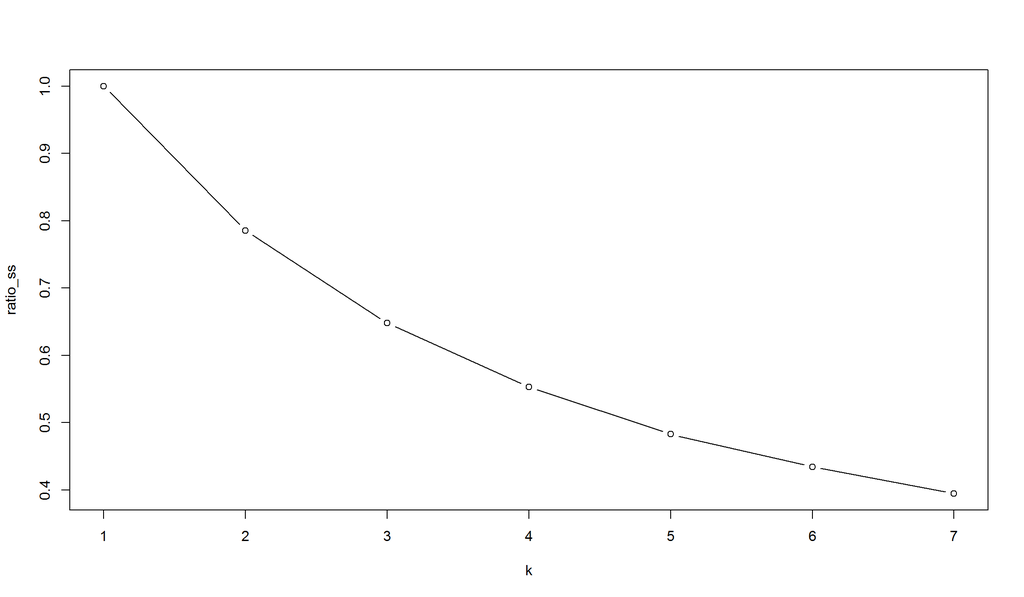

```r
# Initialise ratio_ss
ratio_ss = rep(0)

# Finish the for-loop.
for (k in 1:7) {
     mdl_km = kmeans(airlinesNorm, centers = k, nstart = 20)
     # Save the ratio between of WSS to TSS in kth element of ratio_ss
     ratio_ss[k] = mdl_km$tot.withinss/mdl_km$totss
}

# Make a scree plot with type "b" and xlab "k"
plot(ratio_ss, type="b", xlab="k")
```

As we see, k = 5 seems legitimate.

## Build kmeans model

```r
# Cluster run_record_sc using k-means: mdl_km 5 groups, let R start over 20 times
mdl_km = kmeans(airlinesNorm, centers = 5, nstart = 20, iter.max=1000)
table(mdl_km$cluster)
```

```
##
##    1    2    3    4    5
##  143  776 1373 1650   57
```

```r
mdl_km$centers
```

```
##      Balance   QualMiles  BonusMiles  BonusTrans FlightMiles FlightTrans
## 1  1.1722573  0.42324832  0.66036647  1.74459327  3.78734636  4.05877606
## 2  0.7866778 -0.08547306  1.40214847  1.01145492  0.01417749  0.02211363
## 3 -0.1606061 -0.11505046 -0.34731771 -0.26038231 -0.17602747 -0.19180853
## 4 -0.3517815 -0.14183200 -0.43059094 -0.41272355 -0.20026359 -0.21576712
## 5  0.4009981  6.97876620  0.08495883  0.07250717  0.34260322  0.38252097
##   DaysSinceEnroll
## 1       0.2652869
## 2       0.3859187
## 3       0.8270834
## 4      -0.8886025
## 5      -0.1193065
```

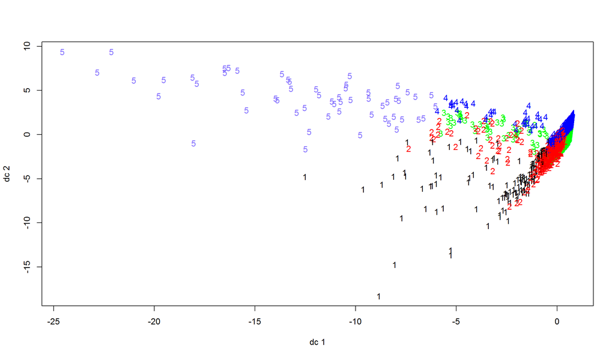

```r
plotcluster(airlinesNorm, mdl_km$cluster)
```

Let’s try different clustering algorithm.

## Build Hierarchical clustering model

```r
airlinesDist = dist(airlinesNorm, method="euclidean")
airlinesHierClust = hclust(airlinesDist, method="ward.D")
clusterGroups = cutree(airlinesHierClust, k = 5)
table(clusterGroups)
```

```
## clusterGroups
##    1    2    3    4    5
##  776  519  494  868 1342
```

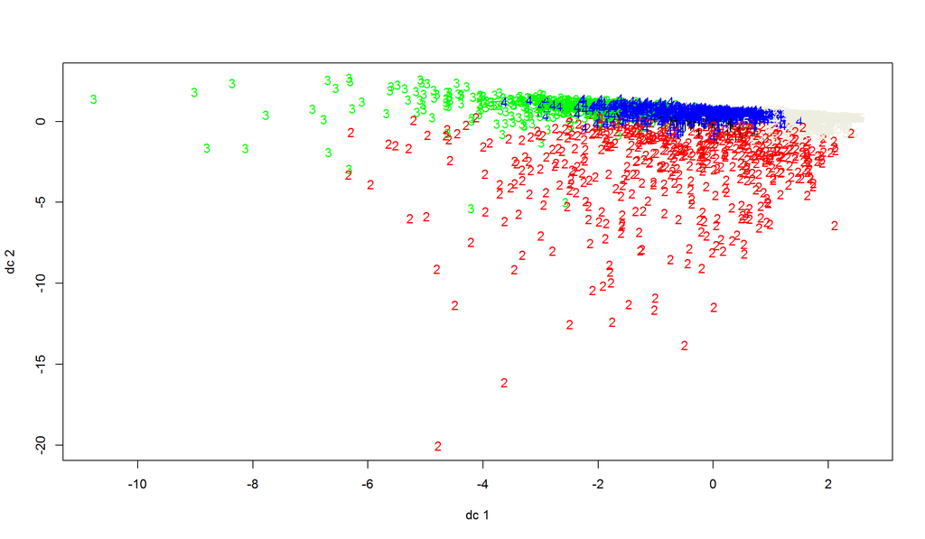

```r
plotcluster(airlinesNorm, clusterGroups)
```

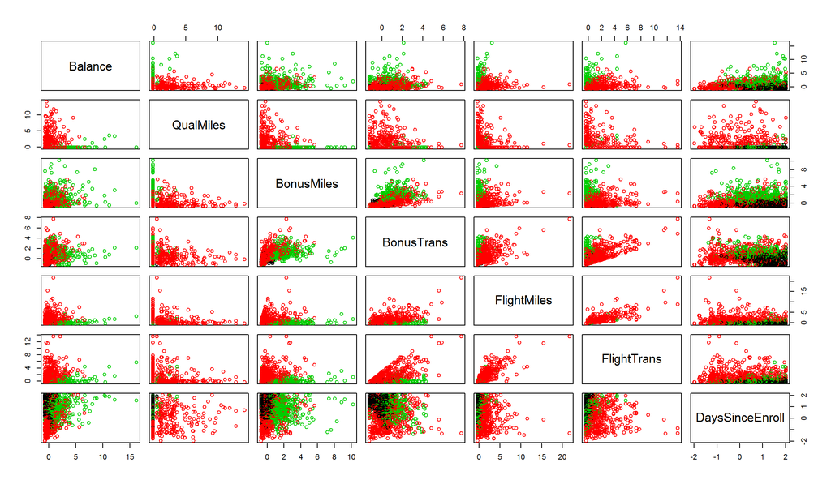

```r
with(airlinesNorm, pairs(airlinesNorm, col=c(1:3)[clusterGroups]))
```

```r
# Now, use tapply to compare the average values in each of the variables for the 5 clusters (the centroids of the clusters). You may want to compute the average values of the unnormalized data so that it is easier to interpret.
balanceAvg = tapply(airlines$Balance, clusterGroups, mean)
qualMilesAvg = tapply(airlines$QualMiles, clusterGroups, mean)
bonusMilesAvg = tapply(airlines$BonusMiles, clusterGroups, mean)
bonusTransAvg = tapply(airlines$BonusTrans, clusterGroups, mean)
flightMilesAvg = tapply(airlines$FlightMiles, clusterGroups, mean)
flightTransAvg = tapply(airlines$FlightTrans, clusterGroups, mean)
daysAvg = tapply(airlines$DaysSinceEnroll, clusterGroups, mean)

df = as.data.frame(cbind(balanceAvg, qualMilesAvg, bonusMilesAvg, bonusTransAvg, flightMilesAvg, flightTransAvg, daysAvg))
df
```

```
##   balanceAvg qualMilesAvg bonusMilesAvg bonusTransAvg flightMilesAvg
## 1   57866.90    0.6443299     10360.124     10.823454       83.18428
## 2  110669.27 1065.9826590     22881.763     18.229287     2613.41811
## 3  198191.57   30.3461538     55795.860     19.663968      327.67611
## 4   52335.91    4.8479263     20788.766     17.087558      111.57373
## 5   36255.91    2.5111773      2264.788      2.973174      119.32191
##   flightTransAvg  daysAvg
## 1      0.3028351 6235.365
## 2      7.4026975 4402.414
## 3      1.0688259 5615.709
## 4      0.3444700 2840.823
## 5      0.4388972 3060.081
```

```r
which.max(df$balanceAvg)
```

```
## [1] 3
```

```r
which.max(df$qualMilesAvg)
```

```
## [1] 2
```

```r
which.max(df$bonusMilesAvg)
```

```
## [1] 3
```

```r
which.max(df$bonusTransAvg)
```

```
## [1] 3
```

```r
which.max(df$flightMilesAvg)
```

```
## [1] 2
```

```r
which.max(df$flightTransAvg)
```

```
## [1] 2
```

```r
which.max(df$daysAvg)
```

```
## [1] 1
```

## Anlaysis

Cluster 1 mostly contains customers with few miles, but who have been with the airline the longest.  
Cluster 2 contains customers with a large amount of miles, mostly accumulated through flight transactions.  
Cluster 3 mostly contains customers with a lot of miles, and who have earned the miles mostly through bonus transactions.  
Cluster 4 customers have the smallest value in DaysSinceEnroll, but they are already accumulating a reasonable number of miles.  
Cluster 5 customers have lower than average values in all variables.